# Assignment 1

Jeevankrishna - 10510202

## Introduction:

My answers to Assignment 1 for B9DA100 are found below.

### Question 1:

#### 1.1

In 1.1, we need to load the carData package and load the `GSSvocab` dataset. The commands needed to do this are:

```r
library(carData)
data(GSSvocab)
```

We also need to look at the top 6 rows of the dataset. The command needed to do this is:

```r
head(GSSvocab)
```

```
##        year gender nativeBorn ageGroup educGroup vocab age educ
## 1978.1 1978 female        yes    50-59    12 yrs    10  52   12
## 1978.2 1978 female        yes      60+   <12 yrs     6  74    9
## 1978.3 1978   male        yes    30-39   <12 yrs     4  35   10
## 1978.4 1978 female        yes    50-59    12 yrs     9  50   12
## 1978.5 1978 female        yes    40-49    12 yrs     6  41   12
## 1978.6 1978   male        yes    18-29    12 yrs     6  19   12
```

#### 1.2

In 1.2, we need to access the description and structure of the dataset. The commands needed to do this are:

```r
?GSSvocab
str(GSSvocab)
```

```
## 'data.frame':    28867 obs. of  8 variables:
##  $ year      : Factor w/ 20 levels "1978","1982",..: 1 1 1 1 1 1 1 1 1 1 ...
##  $ gender    : Factor w/ 2 levels "female","male": 1 1 2 1 1 2 2 2 1 2 ...
##  $ nativeBorn: Factor w/ 2 levels "no","yes": 2 2 2 2 2 2 2 2 2 2 ...
##  $ ageGroup  : Factor w/ 5 levels "18-29","30-39",..: 4 5 2 4 3 1 1 4 3 1 ...
##  $ educGroup : Factor w/ 5 levels "<12 yrs","12 yrs",..: 2 1 1 2 2 2 2 2 4 2 ...
##  $ vocab     : num  10 6 4 9 6 6 4 7 8 3 ...
##  $ age       : num  52 74 35 50 41 19 19 59 49 21 ...
##  $ educ      : num  12 9 10 12 12 12 12 12 16 12 ...
```

##### **Explanation**

**From these commands, we can see that the data comes from National Opinion Research Center of the University of Chicago and contains subjects’s score on a vocabulary test. This data set depicts analysis of a multifactor observational study where factors being age group, eduction level, natality status, gender and survey year.**

#### 1.3

In 1.3, we need to Print the 2,000th row of `GSSvocab`. What is the age of this person? The commands needed to do this are:

```r
GSSvocab[2000,]
```

```
##          year gender nativeBorn ageGroup educGroup vocab age educ
## 1982.468 1982 female        yes      60+    12 yrs     3  66   12
```

```r
GSSvocab$age[2000]
```

```
## [1] 66
```

**Age of Individual at 2000th row is 66**

#### 1.4

In 1.4, we need to Create a new column called `vocab.pct` which is the percentage of the number of words out of 10 correct on the vocabulary test.Print the head of GSSvocab to confirm that this column has attached correctly.The commands needed to do this are:

```r
GSSvocab$vocab.pct<- (GSSvocab$vocab/10)*100

head(GSSvocab)
```

```
##        year gender nativeBorn ageGroup educGroup vocab age educ vocab.pct
## 1978.1 1978 female        yes    50-59    12 yrs    10  52   12       100
## 1978.2 1978 female        yes      60+   <12 yrs     6  74    9        60
## 1978.3 1978   male        yes    30-39   <12 yrs     4  35   10        40
## 1978.4 1978 female        yes    50-59    12 yrs     9  50   12        90
## 1978.5 1978 female        yes    40-49    12 yrs     6  41   12        60
## 1978.6 1978   male        yes    18-29    12 yrs     6  19   12        60
```

#### 1.5

In 1.5, Two of the factors should be ordered factors. Use the help file to help you decide which two. Convert them to ordered factors, and check the structure again to confirm that this has worked.

```r
?GSSvocab
GSSvocab$ageGroup=factor(GSSvocab$ageGroup,ordered = T)
GSSvocab$educGroup=factor(GSSvocab$educGroup,ordered = T)
str(GSSvocab$ageGroup)
```

```
##  Ord.factor w/ 5 levels "18-29"<"30-39"<..: 4 5 2 4 3 1 1 4 3 1 ...
```

```r
str(GSSvocab$educGroup)
```

```
##  Ord.factor w/ 5 levels "<12 yrs"<"12 yrs"<..: 2 1 1 2 2 2 2 2 4 2 ...
```

#### 1.6

In 1.6, we have to Create a table of educational group against age group.The commands needed to do this is:

```r
Edu_age=table(GSSvocab$educGroup,GSSvocab$ageGroup)
Edu_age
```

```
##
##             18-29 30-39 40-49 50-59  60+
##   <12 yrs    1063   812   790   881 2365
##   12 yrs     1848  1785  1528  1306 2118
##   13-15 yrs  1788  1779  1345  1002 1240
##   16 yrs      775  1024   835   576  693
##   >16 yrs     368   833   737   554  655
```

Now to get the combination of Education Group/Age Group with the smallest number of people?

```r
DF_Edu_age=data.frame(Edu_age)
colnames(DF_Edu_age)[1:3]=c("Edu Group","Age Group","Number.of.people")
DF_Edu_age[which.min(DF_Edu_age[,"Number.of.people"]),]
```

```
##   Edu Group Age Group Number.of.people
## 5   >16 yrs     18-29              368
```

**>16yrs and 18-29 is combination of Education group and Age group which has least number of people**

#### 1.7

Produce a clustered barchart of the table in the previous question. Explain in a few lines what the clustered barchart tells us about the relationship between the two variables.

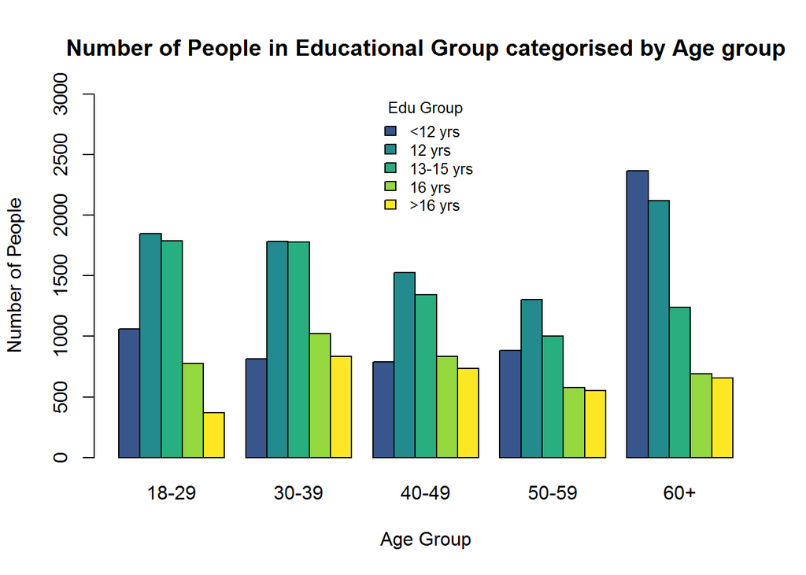

```r
color.names=c("#39568CFF","#238A8DFF","#29AF7FFF","#95D840FF","#FDE725FF")
barplot(Edu_age,beside = T,ylim=c(0,3000),xlab="Age Group",ylab="Number of People",col=color.names
        ,main ="Number of People in Educational Group categorised by Age group")
legend("top",legend=rownames(Edu_age),cex =0.8,title="Edu Group",bty="n",fill = color.names)
```

##### **Explanation**

**Above Clustered barchart illutrates the total number of people that fall under various category of Educational group which is clustered/grouped by Age group of indivdual subject**

### Question 2:

**The dataset diamonds is available in the R package called ggplot2.**

#### 2.1

Install and load the package ggplot2

```r
install.packages("ggplot2")
```

[output not shown]

Load the dataset diamonds. Look at the structure and the top of the dataset.Briey describe the contents of the diamonds dataset. What kind of variables does it contain? How many observations are there?

```r
library(ggplot2)
data("diamonds")
str(diamonds)
```

```
## Classes 'tbl_df', 'tbl' and 'data.frame':    53940 obs. of  10 variables:
##  $ carat  : num  0.23 0.21 0.23 0.29 0.31 0.24 0.24 0.26 0.22 0.23 ...
##  $ cut    : Ord.factor w/ 5 levels "Fair"<"Good"<..: 5 4 2 4 2 3 3 3 1 3 ...
##  $ color  : Ord.factor w/ 7 levels "D"<"E"<"F"<"G"<..: 2 2 2 6 7 7 6 5 2 5 ...
##  $ clarity: Ord.factor w/ 8 levels "I1"<"SI2"<"SI1"<..: 2 3 5 4 2 6 7 3 4 5 ...
##  $ depth  : num  61.5 59.8 56.9 62.4 63.3 62.8 62.3 61.9 65.1 59.4 ...
##  $ table  : num  55 61 65 58 58 57 57 55 61 61 ...
##  $ price  : int  326 326 327 334 335 336 336 337 337 338 ...
##  $ x      : num  3.95 3.89 4.05 4.2 4.34 3.94 3.95 4.07 3.87 4 ...
##  $ y      : num  3.98 3.84 4.07 4.23 4.35 3.96 3.98 4.11 3.78 4.05 ...
##  $ z      : num  2.43 2.31 2.31 2.63 2.75 2.48 2.47 2.53 2.49 2.39 ...
```

```r
head(diamonds)
```

```
## # A tibble: 6 x 10
##   carat cut       color clarity depth table price     x     y     z
##   <dbl> <ord>     <ord> <ord>   <dbl> <dbl> <int> <dbl> <dbl> <dbl>
## 1 0.23  Ideal     E     SI2      61.5    55   326  3.95  3.98  2.43
## 2 0.21  Premium   E     SI1      59.8    61   326  3.89  3.84  2.31
## 3 0.23  Good      E     VS1      56.9    65   327  4.05  4.07  2.31
## 4 0.290 Premium   I     VS2      62.4    58   334  4.2   4.23  2.63
## 5 0.31  Good      J     SI2      63.3    58   335  4.34  4.35  2.75
## 6 0.24  Very Good J     VVS2     62.8    57   336  3.94  3.96  2.48
```

##### **Explanation**

**Daimond is a dataset containing the prices and other attributes such as carat, cut,color,clarity,depth,table of each observation. In this dataset, 53940 observations are available with 10 variables. Data type of these variable being *Num*, *int* and *Ordered factor* .**

#### 2.2

Are there any missing values in the dataset?

```r
anyNA(diamonds)
```

```
## [1] FALSE
```

**There are no missing values in the dataset**

#### 2.3

Which row contains the diamond with a depth of 70? What colour is this diamond?

```r
which(diamonds$depth=="70")
```

```
## [1] 11779
```

```r
#To get color of diamond with depth value "70"
diamonds[which(diamonds$depth=="70"),"color"]
```

```
## # A tibble: 1 x 1
##   color
##   <ord>
## 1 J
```

```r
#alternatively
diamonds$color[which(diamonds$depth=="70")]
```

```
## [1] J
## Levels: D < E < F < G < H < I < J
```

**`J` is the color of the diamond with depth value=70**

#### 2.4

Use the summary() function on diamonds. Describe the results for any two of the variables.

```r
summary(diamonds)
```

```
##      carat               cut        color        clarity
##  Min.   :0.2000   Fair     : 1610   D: 6775   SI1    :13065
##  1st Qu.:0.4000   Good     : 4906   E: 9797   VS2    :12258
##  Median :0.7000   Very Good:12082   F: 9542   SI2    : 9194
##  Mean   :0.7979   Premium  :13791   G:11292   VS1    : 8171
##  3rd Qu.:1.0400   Ideal    :21551   H: 8304   VVS2   : 5066
##  Max.   :5.0100                     I: 5422   VVS1   : 3655
##                                     J: 2808   (Other): 2531
##      depth           table           price             x
##  Min.   :43.00   Min.   :43.00   Min.   :  326   Min.   : 0.000
##  1st Qu.:61.00   1st Qu.:56.00   1st Qu.:  950   1st Qu.: 4.710
##  Median :61.80   Median :57.00   Median : 2401   Median : 5.700
##  Mean   :61.75   Mean   :57.46   Mean   : 3933   Mean   : 5.731
##  3rd Qu.:62.50   3rd Qu.:59.00   3rd Qu.: 5324   3rd Qu.: 6.540
##  Max.   :79.00   Max.   :95.00   Max.   :18823   Max.   :10.740
##
##        y                z
##  Min.   : 0.000   Min.   : 0.000
##  1st Qu.: 4.720   1st Qu.: 2.910
##  Median : 5.710   Median : 3.530
##  Mean   : 5.735   Mean   : 3.539
##  3rd Qu.: 6.540   3rd Qu.: 4.040
##  Max.   :58.900   Max.   :31.800
##
```

```r
str(diamonds$cut)
```

```
##  Ord.factor w/ 5 levels "Fair"<"Good"<..: 5 4 2 4 2 3 3 3 1 3 ...
```

##### **Explanation**

**`Cut` and `Color` are 2 variable among 10 variable available in dataset.**

- `Cut` is an ordered factor, providing information on quality of cut in diamond from (Fair, Good, Very Good, Premium, Ideal)
- `Color` is also an ordered factor, providing information on diamons color being worst to best. where D being best and J being worst. We have more number diamond that fall under “G” in color variable

#### 2.5

Create a table of color against cut.

```r
table(diamonds$color, diamonds$cut)
```

```
##
##     Fair Good Very Good Premium Ideal
##   D  163  662      1513    1603  2834
##   E  224  933      2400    2337  3903
##   F  312  909      2164    2331  3826
##   G  314  871      2299    2924  4884
##   H  303  702      1824    2360  3115
##   I  175  522      1204    1428  2093
##   J  119  307       678     808   896
```

Write some code to find the colour/cut combination with the smallest number of diamonds.

```r
combination_df=data.frame(table(diamonds$color, diamonds$cut))
colnames(combination_df)[1:3]=c("color","cut","count.of.Diamond")
combination_df[which.min(combination_df[,"count.of.Diamond"]),]
```

```
##   color  cut count.of.Diamond
## 7     J Fair              119
```

**J and Fair are color and cut combination with the least number of diamonds**

#### 2.6

Using the table from the previous question, produce a table showing proportions (in- stead of counts) and marginal sums. Print this new table, and comment on it.

```r
prop_table=prop.table(table(diamonds$color, diamonds$cut))
margin.table(prop.table(table(diamonds$color, diamonds$cut)))
```

```
## [1] 1
```

```r
print(prop_table)
```

```
##
##            Fair        Good   Very Good     Premium       Ideal
##   D 0.003021876 0.012272896 0.028049685 0.029718205 0.052539859
##   E 0.004152762 0.017296997 0.044493882 0.043325918 0.072358176
##   F 0.005784205 0.016852058 0.040118650 0.043214683 0.070930664
##   G 0.005821283 0.016147571 0.042621431 0.054208380 0.090545050
##   H 0.005617353 0.013014461 0.033815350 0.043752317 0.057749351
##   I 0.003244346 0.009677419 0.022321098 0.026473860 0.038802373
##   J 0.002206155 0.005691509 0.012569522 0.014979607 0.016611049
```

###### **Comment**

**Marginal sum of `prop_table` is 1 as count of diamond in each combination is divided by total number of observation.marginal sum of all the values in `prop_table` will be 1. but if we take proportion based on row-wise, Then marginal sum would be 7 as there are 7 rows in table. Similarly if we take proportion based on coloumn-wise, then marginal sum would be 5 as there are 5 coloumn in `prop_table`.**

#### 2.7

According to this dataset, what is the size (length, width and depth in mm) of the most expensive diamond?

```r
diamonds[which.max(diamonds$price),8:10]
```

```
## # A tibble: 1 x 3
##       x     y     z
##   <dbl> <dbl> <dbl>
## 1   8.5  8.47  5.16
```

#### 2.8

Which are the 7 most expensive prices for diamonds of clarity IF

```r
# Subset of Diamond data set with clarity="IF"

Clarity_IF=diamonds[(which(diamonds$clarity=="IF")),]
#head(Clarity_IF)

#Sorting prices list in decreasing order

Expensive_7=sort(Clarity_IF$price,decreasing = T)

# Displaying 7 most expensive prices
Expensive_7[1:7]
```

```
## [1] 18806 18700 18594 18552 18542 18435 18426
```

#### 2.9

How many diamonds are of Ideal cut, best colour and best clarity?

```r
nrow(diamonds[which((diamonds$cut=="Ideal")&((diamonds$color=="D")&(diamonds$clarity=="IF"))),])
```

```
## [1] 28
```

There are 28 Diamonds with Ideal cut, best color and better clarity.

#### 2.10

Create a new column called price.per.carat which contains the price of a diamond divided by its carat.

```r
diamonds$price.per.carat= diamonds$price/diamonds$carat
head(diamonds)
```

```
## # A tibble: 6 x 11
##   carat cut   color clarity depth table price     x     y     z
##   <dbl> <ord> <ord> <ord>   <dbl> <dbl> <int> <dbl> <dbl> <dbl>
## 1 0.23  Ideal E     SI2      61.5    55   326  3.95  3.98  2.43
## 2 0.21  Prem~ E     SI1      59.8    61   326  3.89  3.84  2.31
## 3 0.23  Good  E     VS1      56.9    65   327  4.05  4.07  2.31
## 4 0.290 Prem~ I     VS2      62.4    58   334  4.2   4.23  2.63
## 5 0.31  Good  J     SI2      63.3    58   335  4.34  4.35  2.75
## 6 0.24  Very~ J     VVS2     62.8    57   336  3.94  3.96  2.48
## # ... with 1 more variable: price.per.carat <dbl>
```

#### 2.11

Create a subset of diamonds called sub.diamonds which contains only those diamonds of cut Ideal. How many observations are there in sub.diamonds?

```r
sub.diamonds=subset(diamonds,diamonds$cut=="Ideal")
#sub.diamonds=diamonds[which(diamonds$cut=="Ideal"),]
nrow(sub.diamonds)
```

```
## [1] 21551
```

#### 2.12

Use the aggregate() function to aggregate the price.per.carat column of sub.diamonds to find the mean of this variable for every clarity and color combination. Save this output as a dataframe called df1.

```r
df1= aggregate(sub.diamonds$price.per.carat,list(sub.diamonds$clarity,sub.diamonds$color),mean)
colnames(df1)[1:3]= c( "Clarity", "Color", "Mean.price.per.carat")
head(df1)
```

```
##   Clarity Color Mean.price.per.carat
## 1      I1     D             2898.389
## 2     SI2     D             3453.319
## 3     SI1     D             3398.575
## 4     VS2     D             3521.434
## 5     VS1     D             3969.296
## 6    VVS2     D             5023.537
```

#### 2.13

Order df1 by descending price per carat. Comment on the results.

```r
df1[order(-df1$Mean.price.per.carat,df1$Clarity,df1$Color),]
```

```
##    Clarity Color Mean.price.per.carat
## 8       IF     D             9034.177
## 6     VVS2     D             5023.537
## 16      IF     E             4975.468
## 7     VVS1     D             4860.549
## 30    VVS2     G             4530.858
## 22    VVS2     F             4511.928
## 42     SI2     I             4508.587
## 29     VS1     G             4487.384
## 28     VS2     G             4372.454
## 21     VS1     F             4324.246
## 34     SI2     H             4249.712
## 23    VVS1     F             4182.076
## 50     SI2     J             4147.780
## 35     SI1     H             4134.589
```

[output cut: 42 more lines]

##### **Comment**

**Above result give a quick insight on `Mean.price.per.carat` of diamond based on `Clarity` and `color`. As `df1` is ordered by descending value of `Price.per.carat`, we can observe that a diamond with highest price is in first row with `clarity` being `"IF"` which is better clarity and `Color` being `"D"` which is best in color.**

**Similarly, if we consider the last row of the table we can observe that `clarity` has value `"VVS1"` which is second best clarity of diamond in this data set and `color` being `"J"` which is worst color for diamond. Here`price.per.carat` is very less even with the good clarity.**

#### 2.14

Be creative - produce an interesting table, a plot, or create a new variable which helps to tell us something new about the diamonds dataset. Describe your findings.

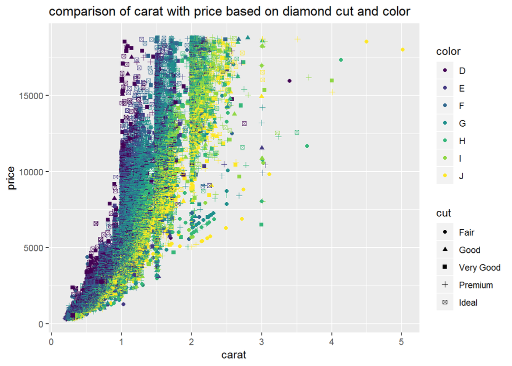

```r
require(ggplot2)

#scatterplot for carat against price based on diamond's cut and color

ggplot(diamonds[,],aes(x=carat,y=price))+geom_jitter(aes(color=color,shape=cut))+
labs(title="comparison of carat with price based on diamond cut and color")
```

##### Findings

- Price of Diamond is Low at carat value between 0 and 1. price Increases drastically for carat value more than 1.
- we can observe shade of yellow(J-worst color) and purple(D-Best color) in all price range.
- similarly, We can observe both Fair cut and ideal cut diamond with high price as well as low prices.

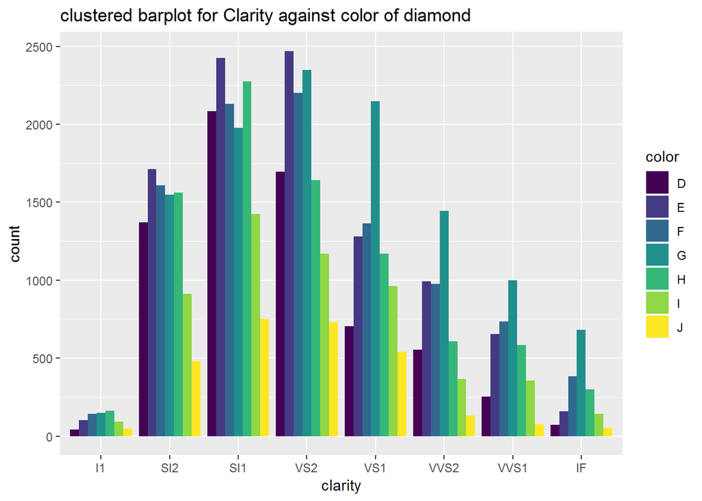

```r
#clustered barplot for Clarity against color of diamond
ggplot(diamonds,aes(x=clarity,fill=color))+geom_bar(position="dodge")+labs(title="clustered barplot for Clarity against color of diamond")
```

##### Findings

- Here we have considered, Color and clarity of diamond data set. X- axis represent Clarity which is ordered factor and Y- axis provides information on count of diamonds that fall under particular category of clarity. Then this data is coupled with color attribute to obtain clustered bar plot.
- we can observe that Number of diamonds in VS2 and SI1 are compartively higher than rest of the clarity category.
- Likewise, Every clarity category from VS1 to IF has more number of diamonds with Color category of “G”.
- We can also observe that the diamond with good color and better Clarity is very less in number. it’s same in the case of worst color and least clarity diamond too.

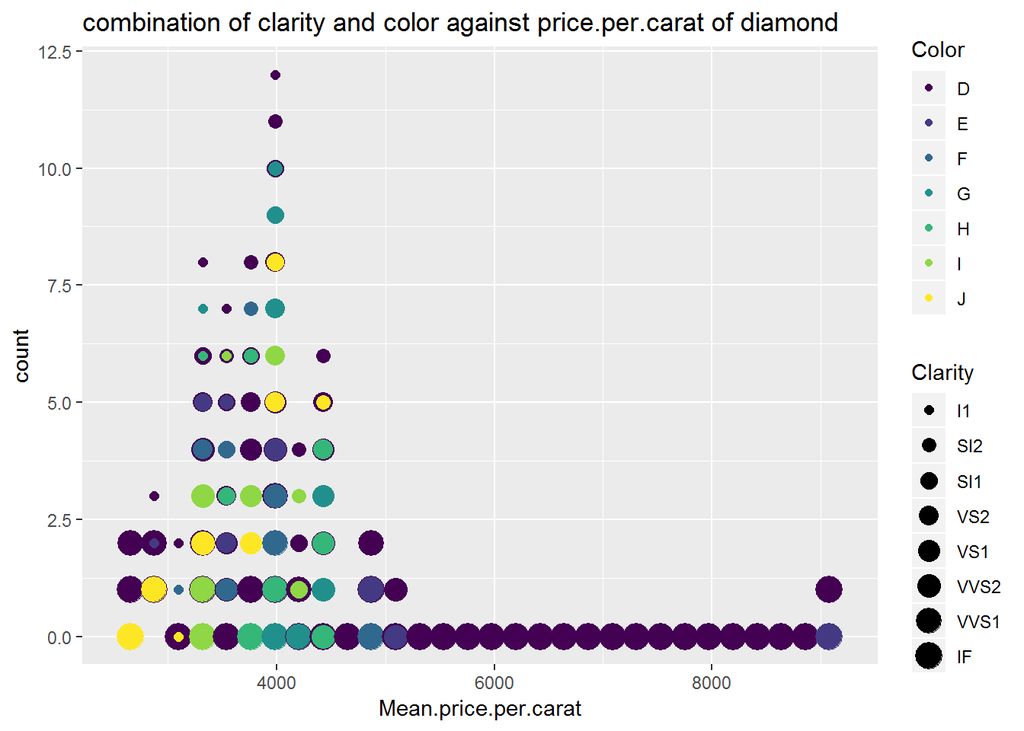

```r
# Used a data frame df1 from previous question.
ggplot(df1[],aes(x=Mean.price.per.carat,color=Color))+stat_bin(geom = "point",bins = 30, aes(size= Clarity))+labs(title="combination of clarity and color against price.per.carat of diamond")
```

##### Findings

Demand and supply being root for economic system, when there is less supply of diamond with better clarity and color, price of such diamond become directly proportional to demand in market. Based on above plot there is very few diamond with better clarity and color with price being more than $8000. So this says there is high demand for the dimond with clarity of “IF” and color of “D”.